# Pesola_Ella_A1_Regression

## Introduction

```python
## importing libraries ##

import numpy as np  # For numerical operations
import pandas as pd  # For data manipulation
import sklearn.linear_model  # For linear modeling
import seaborn as sns  # For statistical data visualization
import matplotlib.pyplot as plt  # For plotting
from dateutil.parser import parse  # For parsing dates
from sklearn.linear_model import SGDRegressor  # For performing stochastic gradient descent regression
from sklearn.neighbors import KNeighborsRegressor  # For performing regression based on the k-Nearest Neighbors algorithm
from sklearn import tree  # For decision tree algorithms
from sklearn.model_selection import GridSearchCV  # For optimizing model parameters through cross-validation
from sklearn.linear_model import Ridge  # For performing ridge regression
from sklearn.linear_model import Lasso  # For performing lasso regression
from sklearn.metrics import mean_squared_error, r2_score  # For calculating model performance metrics
from sklearn.linear_model import LinearRegression  # For performing ordinary least squares linear regression
from sklearn.tree import DecisionTreeRegressor, plot_tree  # For decision tree regression and plotting the tree
from sklearn.preprocessing import OneHotEncoder, StandardScaler, MinMaxScaler  # For preprocessing data by encoding, standardizing, and scaling
from sklearn.model_selection import train_test_split  # For splitting data into training and testing sets


#!###############################!#
#!# import additional libraries #!#
#!###############################!#
# import whatever you need


# setting pandas print options (optional)
pd.set_option('display.max_rows', 500)
pd.set_option('display.max_columns', 500)
pd.set_option('display.width', 1000)
```

```python
## importing data ##

# reading modeling data into Python
modeling_data = './datasets/train.xlsx'

# calling this df_train
df_train = pd.read_excel(io         = modeling_data,
                         sheet_name = 'data',
                         header     = 0,
                         index_col  = 'ID')



# reading testing data into Python
testing_data = './datasets/test.xlsx'

# calling this df_test
df_test = pd.read_excel(io         = testing_data,
                        sheet_name = 'data',
                        header     = 0,
                        index_col  = 'ID')
```

```python
# concatenating datasets together for mv analysis and feature engineering
df_train['set'] = 'Not Kaggle'
df_test ['set'] = 'Kaggle'

# concatenating both datasets together for mv and feature engineering
df_full = pd.concat(objs = [df_train, df_test],
                    axis = 0,
                    ignore_index = False)


# checking data
df_full.head(n = 5)
```

| ID | DateHour | Temperature(F) | Humidity(%) | Wind speed (mph) | Visibility(miles) | DewPointTemperature(F) | Rainfall(in) | Snowfall(in) | SolarRadiation(MJ/m2) | Holiday | FunctioningDay | RENTALS | set |
| --- | --- | --- | --- | --- | --- | --- | --- | --- | --- | --- | --- | --- | --- |
| mb_1039 | 2023-10-14 05:59:54.810000 | 52 | 81 | 0.4 | 2.9 | 46.4 | 0.0 | 0.0 | 0.00 | No | Yes | 519.0 | Not Kaggle |
| mb_1330 | 2023-10-26 08:59:53.355000 | 51 | 53 | 2.2 | NaN | 35.2 | 0.0 | 0.0 | 1.01 | No | Yes | 1251.0 | Not Kaggle |
| mb_551 | 2023-09-23 21:59:57.250000 | 56 | 49 | 2.5 | 3.4 | 38.8 | 0.0 | 0.0 | 0.00 | No | Yes | 1685.0 | Not Kaggle |
| mb_2103 | 2023-12-19 14:00:00 | 69 | 32 | 9.8 | 12.4 | 38.7 | 0.0 | 0.0 | 2.36 | No | No | 0.0 | Not Kaggle |
| mb_1430 | 2023-10-30 12:59:52.855000 | 53 | 20 | 2.9 | 10.8 | 12.9 | 0.0 | 0.0 | 1.96 | No | Yes | 814.0 | Not Kaggle |

```python
# checking available features
df_full.columns
```

```
Index(['DateHour', 'Temperature(F)', 'Humidity(%)', 'Wind speed (mph)', 'Visibility(miles)', 'DewPointTemperature(F)', 'Rainfall(in)', 'Snowfall(in)', 'SolarRadiation(MJ/m2)', 'Holiday', 'FunctioningDay', 'RENTALS', 'set'], dtype='object')
```

```python
#!##############################!#
#!# set your response variable #!#
#!##############################!#
y_variable = 'RENTALS' # this should be a string
```

## Part II: Data Preparation

### Missing Value Analysis and Imputation

This project's preparation and exploratory data analysis stages were essential for figuring out the structure of the dataset and getting it ready for modeling. First, a review of the missing values indicated differences in a number of variables, most notably 'Visibility(miles)', 'DewPointTemperature(F)', and 'SolarRadiation(MJ/m2)'. The skewness in the distributions of these attributes was taken into consideration when applying the mean and median imputation techniques to solve this. This careful process made sure that the imputed values were representative and did not contaminate the dataset with bias.

At the preprocessing stage, converting object and category data into numerical forms is essential for later stage modeling. More detailed examination of temporal patterns in bike rentals was made possible by the conversion of the 'DateHour' column into separate 'hour', 'day_of_week', and'month' columns. In a similar vein, the mapping of 'Holiday' and 'FunctioningDay' to binary integer representations made it easier to incorporate them into the modeling process and improved the models' capacity to identify patterns about operational status and holiday incidence.

To handle categorical data and standardize the data range, respectively, one-hot encoding of numerical features and scaling of numerical features were also conducted. This preprocessing reduced scale disparities and transformed categorical variables into a machine-readable format, which not only made the dataset more manageable but also increased the effectiveness of the prediction models.

The correlations between the variables were further clarified by a correlation matrix, which showed, in particular, the positive association between "FunctioningDay," "hour," and "Temperature(F)" and "RENTALS." This realization emphasizes how important operating hours, the time of day, and the weather are in forecasting demand for bike rentals, also affecting my decision making on the feature engineering stage.

```python
## Missing Value Imputation ##

# Find missing values in the training dataset
missing_values_train = df_train.isnull().sum()

# Find missing values in the test dataset
missing_values_test = df_test.isnull().sum()

# Print out the missing values for both datasets
print("Missing values in training dataset:\n", missing_values_train)
print("\nMissing values in test dataset:\n", missing_values_test)

missing_values_df_full = df_full.isnull().sum()

print("Missing values in full dataset:\n", missing_values_df_full)
```

```
Missing values in training dataset:
 DateHour                   0
Temperature(F)             0
Humidity(%)                0
Wind speed (mph)           0
Visibility(miles)         63
DewPointTemperature(F)    51
Rainfall(in)               0
Snowfall(in)               0
SolarRadiation(MJ/m2)     80
Holiday                    0
FunctioningDay             0
RENTALS                    0
set                        0
dtype: int64

Missing values in test dataset:
 DateHour                   0
Temperature(F)             0
Humidity(%)                0
Wind speed (mph)           0
Visibility(miles)         13
DewPointTemperature(F)    16
Rainfall(in)               0
Snowfall(in)               0
SolarRadiation(MJ/m2)     26
Holiday                    0
FunctioningDay             0
set                        0
dtype: int64
Missing values in full dataset:
 DateHour                    0
Temperature(F)              0
Humidity(%)                 0
Wind speed (mph)            0
Visibility(miles)          76
DewPointTemperature(F)     67
Rainfall(in)                0
Snowfall(in)                0
SolarRadiation(MJ/m2)     106
Holiday                     0
FunctioningDay              0
RENTALS                   546
set                         0
dtype: int64
```

```python
 # looping to flag features with missing values
for flag in df_full:

    # creating columns with 1s if missing and 0 if not
    if df_full[flag].isnull().astype(int).sum() > 0:
        df_full['m_'+flag] = df_full[flag].isnull().astype(int)
```

```python
# checking results - summing missing value flags
df_full[ ['m_Visibility(miles)', 'm_DewPointTemperature(F)', 'm_SolarRadiation(MJ/m2)'] ].sum(axis = 0)
```

```
m_Visibility(miles)          76
m_DewPointTemperature(F)     67
m_SolarRadiation(MJ/m2)     106
dtype: int64
```

```python
# subsetting for missing value features
mv_flag_check = df_full[ ['Visibility(miles)'     , 'm_Visibility(miles)',
                          'DewPointTemperature(F)' , 'm_DewPointTemperature(F)',
                          'SolarRadiation(MJ/m2)', 'm_SolarRadiation(MJ/m2)'] ]


# checking results - feature comparison
mv_flag_check.sort_values(by = ['m_Visibility(miles)', 'm_DewPointTemperature(F)', 'm_SolarRadiation(MJ/m2)'],
                          ascending = False).head(n = 10)
```

| ID | Visibility(miles) | m_Visibility(miles) | DewPointTemperature(F) | m_DewPointTemperature(F) | SolarRadiation(MJ/m2) | m_SolarRadiation(MJ/m2) |
| --- | --- | --- | --- | --- | --- | --- |
| mb_004 | NaN | 1 | NaN | 1 | 0.00 | 0 |
| mb_006 | NaN | 1 | NaN | 1 | 0.00 | 0 |
| mb_1926 | NaN | 1 | 34.0 | 0 | NaN | 1 |
| mb_2046 | NaN | 1 | 34.2 | 0 | NaN | 1 |
| mb_2041 | NaN | 1 | 36.0 | 0 | NaN | 1 |
| mb_2048 | NaN | 1 | 33.3 | 0 | NaN | 1 |
| mb_2047 | NaN | 1 | 33.4 | 0 | NaN | 1 |
| mb_1330 | NaN | 1 | 35.2 | 0 | 1.01 | 0 |
| mb_1099 | NaN | 1 | 67.3 | 0 | 0.17 | 0 |
| mb_2049 | NaN | 1 | 31.1 | 0 | 0.24 | 0 |

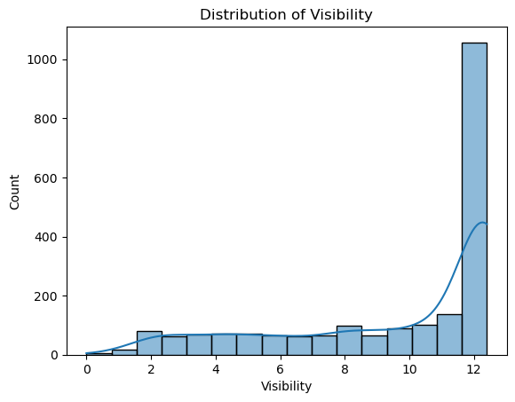

```python
# plotting 'Visibility(miles)'
sns.histplot(x = 'Visibility(miles)',
            data = df_full,
            kde = True)


# title and labels
plt.title (label  = 'Distribution of Visibility')
plt.xlabel(xlabel = 'Visibility')
plt.ylabel(ylabel = 'Count')


# displaying the plot
plt.show()
```

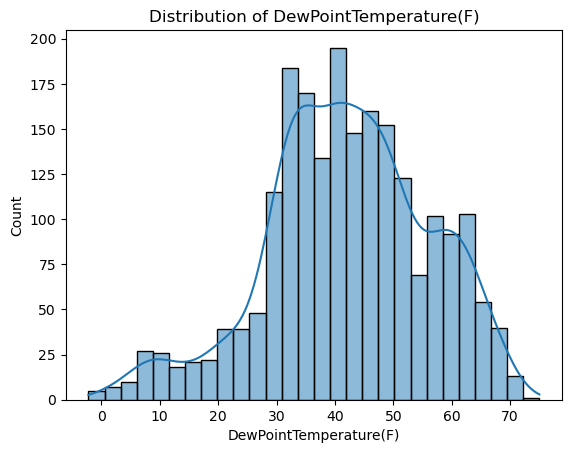

```python
# plotting 'DewPointTemperature(F)'
sns.histplot(x = 'DewPointTemperature(F)',
            data = df_full,
            kde = True)


# title and labels
plt.title (label  = 'Distribution of DewPointTemperature(F)')
plt.xlabel(xlabel = 'DewPointTemperature(F)')
plt.ylabel(ylabel = 'Count')


# displaying the plot
plt.show()
```

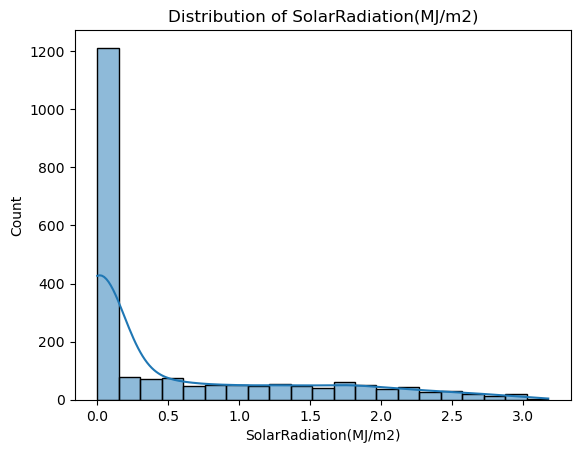

```python
# plotting 'SolarRadiation(MJ/m2)'
sns.histplot(x = 'SolarRadiation(MJ/m2)',
            data = df_full,
            kde = True)


# title and labels
plt.title (label  = 'Distribution of SolarRadiation(MJ/m2)')
plt.xlabel(xlabel = 'SolarRadiation(MJ/m2)')
plt.ylabel(ylabel = 'Count')


# displaying the plot
plt.show()
```

```python
# Calculate median and mean for columns for imputation
visibility_median_full = df_full['Visibility(miles)'].median()
solar_radiation_median_full = df_full['SolarRadiation(MJ/m2)'].median()
dew_point_temp_mean_full = df_full['DewPointTemperature(F)'].mean()

# Apply the median and mean imputation to df_full
df_full['Visibility(miles)'].fillna(visibility_median_full, inplace=True)
df_full['SolarRadiation(MJ/m2)'].fillna(solar_radiation_median_full, inplace=True)
df_full['DewPointTemperature(F)'].fillna(dew_point_temp_mean_full, inplace=True)


# Check for remaining missing values
remaining_missing_full = df_full.isnull().sum()

# Print the results
print("Remaining missing values in df_full:\n", remaining_missing_full)
```

```
Remaining missing values in df_full:
 DateHour                      0
Temperature(F)                0
Humidity(%)                   0
Wind speed (mph)              0
Visibility(miles)             0
DewPointTemperature(F)        0
Rainfall(in)                  0
Snowfall(in)                  0
SolarRadiation(MJ/m2)         0
Holiday                       0
FunctioningDay                0
RENTALS                     546
set                           0
m_Visibility(miles)           0
m_DewPointTemperature(F)      0
m_SolarRadiation(MJ/m2)       0
m_RENTALS                     0
dtype: int64
```

```python
df_full.describe()
```

|  | Temperature(F) | Humidity(%) | Wind speed (mph) | Visibility(miles) | DewPointTemperature(F) | Rainfall(in) | Snowfall(in) | SolarRadiation(MJ/m2) | RENTALS | m_Visibility(miles) | m_DewPointTemperature(F) | m_SolarRadiation(MJ/m2) | m_RENTALS |
| --- | --- | --- | --- | --- | --- | --- | --- | --- | --- | --- | --- | --- | --- |
| count | 2184.000000 | 2184.000000 | 2184.000000 | 2184.000000 | 2184.000000 | 2184.000000 | 2184.000000 | 2184.000000 | 1638.000000 | 2184.000000 | 2184.000000 | 2184.000000 | 2184.000000 |
| mean | 57.389652 | 59.228480 | 3.344780 | 9.718407 | 42.036089 | 0.004858 | 0.002015 | 0.520604 | 828.153846 | 0.034799 | 0.030678 | 0.048535 | 0.250000 |
| std | 12.861669 | 18.686445 | 2.071144 | 3.451659 | 13.781186 | 0.037354 | 0.018550 | 0.799339 | 657.599846 | 0.183311 | 0.172482 | 0.214943 | 0.433112 |
| min | 26.000000 | 13.000000 | 0.000000 | 0.000000 | -2.200000 | 0.000000 | 0.000000 | 0.000000 | 0.000000 | 0.000000 | 0.000000 | 0.000000 | 0.000000 |
| 25% | 48.000000 | 44.000000 | 1.800000 | 7.600000 | 33.600000 | 0.000000 | 0.000000 | 0.000000 | 241.500000 | 0.000000 | 0.000000 | 0.000000 | 0.000000 |
| 50% | 57.000000 | 59.000000 | 2.900000 | 11.700000 | 42.036089 | 0.000000 | 0.000000 | 0.000000 | 761.500000 | 0.000000 | 0.000000 | 0.000000 | 0.000000 |
| 75% | 68.000000 | 74.000000 | 4.500000 | 12.400000 | 51.100000 | 0.000000 | 0.000000 | 0.900000 | 1203.750000 | 0.000000 | 0.000000 | 0.000000 | 0.250000 |
| max | 91.000000 | 97.000000 | 12.800000 | 12.400000 | 75.000000 | 0.710000 | 0.300000 | 3.180000 | 3303.000000 | 1.000000 | 1.000000 | 1.000000 | 1.000000 |

```python
df_full.info()
```

```
<class 'pandas.core.frame.DataFrame'>
Index: 2184 entries, mb_1039 to mb_1225
Data columns (total 17 columns):
 #   Column                    Non-Null Count  Dtype
---  ------                    --------------  -----
 0   DateHour                  2184 non-null   object
 1   Temperature(F)            2184 non-null   int64
 2   Humidity(%)               2184 non-null   int64
 3   Wind speed (mph)          2184 non-null   float64
 4   Visibility(miles)         2184 non-null   float64
 5   DewPointTemperature(F)    2184 non-null   float64
 6   Rainfall(in)              2184 non-null   float64
 7   Snowfall(in)              2184 non-null   float64
 8   SolarRadiation(MJ/m2)     2184 non-null   float64
 9   Holiday                   2184 non-null   object
 10  FunctioningDay            2184 non-null   object
 11  RENTALS                   1638 non-null   float64
 12  set                       2184 non-null   object
 13  m_Visibility(miles)       2184 non-null   int64
 14  m_DewPointTemperature(F)  2184 non-null   int64
 15  m_SolarRadiation(MJ/m2)   2184 non-null   int64
 16  m_RENTALS                 2184 non-null   int64
dtypes: float64(7), int64(6), object(4)
memory usage: 371.7+ KB
```

### Transformations

To initiate the creation of new variables through feature engineering, it's necessary to convert certain data from categorical and object types into numerical forms, specifically integers and floats. This process begins by breaking down the **DateHour** column into three distinct columns: **hour**, **Day_of_week**, and **month**. Additionally, the datatypes for **Holiday** and **FunctioningDay** are altered from objects to integers, providing numerical values that can be used for further feature development.

```python
# Check the format of 'DateHour' data to avoid NaT values
sample_dates = df_full['DateHour'].dropna().head()

sample_dates
```

```
ID
mb_1039    2023-10-14 05:59:54.810000
mb_1330    2023-10-26 08:59:53.355000
mb_551     2023-09-23 21:59:57.250000
mb_2103           2023-12-19 14:00:00
mb_1430    2023-10-30 12:59:52.855000
Name: DateHour, dtype: object
```

```python
# Format the 'DateHour' values
def parse_date(date_str):
    formats = ['%Y-%m-%d %H:%M:%S.%f', '%Y-%m-%d %H:%M:%S', '%m/%d/%Y %H:%M']
    for fmt in formats:
        try:
            return pd.to_datetime(date_str, format=fmt)
        except ValueError:
            continue
    try:
        # As a last resort, try to infer the format of the date
        return parse(date_str, fuzzy_with_tokens=False)
    except ValueError:
        # If unable to parse the date string
        return pd.NaT  # Return NaT if all formats fail

# Apply the function to the DateHour column
df_full['DateHour'] = df_full['DateHour'].apply(parse_date)
```

```python
# Check how many NaT values are there after the conversion
nat_counts = df_full['DateHour'].isna().sum()

# Display rows where DateHour is NaT
nat_rows = df_full[df_full['DateHour'].isna()]

# Show the count of NaT values and the first few rows with NaT
nat_counts, nat_rows.head()
```

```
(0,
 Empty DataFrame
 Columns: [DateHour, Temperature(F), Humidity(%), Wind speed (mph), Visibility(miles), DewPointTemperature(F), Rainfall(in), Snowfall(in), SolarRadiation(MJ/m2), Holiday, FunctioningDay, RENTALS, set, m_Visibility(miles), m_DewPointTemperature(F), m_SolarRadiation(MJ/m2), m_RENTALS]
 Index: [])
```

```python
# Extract date-time features
df_full['hour'] = df_full['DateHour'].dt.hour
df_full['day_of_week'] = df_full['DateHour'].dt.dayofweek
df_full['month'] = df_full['DateHour'].dt.month
```

```python
# Change the datatype of 'Holiday' and 'FunctioningDay' from object to

# Assuming 'Yes' = 1 and 'No' = 0
df_full['Holiday'] = df_full['Holiday'].map({'No': 0, 'Yes': 1}).astype(int)
df_full['FunctioningDay'] = df_full['FunctioningDay'].map({'No': 0, 'Yes': 1}).astype(int)
```

```python
df_full.info() # Check the datatype of new variables
```

```
<class 'pandas.core.frame.DataFrame'>
Index: 2184 entries, mb_1039 to mb_1225
Data columns (total 20 columns):
 #   Column                    Non-Null Count  Dtype
---  ------                    --------------  -----
 0   DateHour                  2184 non-null   datetime64[ns]
 1   Temperature(F)            2184 non-null   int64
 2   Humidity(%)               2184 non-null   int64
 3   Wind speed (mph)          2184 non-null   float64
 4   Visibility(miles)         2184 non-null   float64
 5   DewPointTemperature(F)    2184 non-null   float64
 6   Rainfall(in)              2184 non-null   float64
 7   Snowfall(in)              2184 non-null   float64
 8   SolarRadiation(MJ/m2)     2184 non-null   float64
 9   Holiday                   2184 non-null   int64
 10  FunctioningDay            2184 non-null   int64
 11  RENTALS                   1638 non-null   float64
 12  set                       2184 non-null   object
 13  m_Visibility(miles)       2184 non-null   int64
 14  m_DewPointTemperature(F)  2184 non-null   int64
 15  m_SolarRadiation(MJ/m2)   2184 non-null   int64
 16  m_RENTALS                 2184 non-null   int64
 17  hour                      2184 non-null   int32
 18  day_of_week               2184 non-null   int32
 19  month                     2184 non-null   int32
dtypes: datetime64[ns](1), float64(7), int32(3), int64(8), object(1)
memory usage: 397.3+ KB
```

```python
# Dropping the original DateHour column
df_full.drop('DateHour', axis=1, inplace=True)

# Encoding categorical variables
encoder_category = OneHotEncoder(drop='first')
df_full_encoded = encoder_category.fit_transform(df_full[['Holiday', 'FunctioningDay']])

# One-Hot Encoding for 'hour', 'day_of_week', and 'month'
encoder = OneHotEncoder(drop='first')
cyclic_features_encoded = encoder.fit_transform(df_full[['hour', 'day_of_week', 'month']])

# Scaling numerical features
scaler = StandardScaler()
numerical_features = ['Temperature(F)', 'Humidity(%)', 'DewPointTemperature(F)', 'SolarRadiation(MJ/m2)']
df_full[numerical_features] = scaler.fit_transform(df_full[numerical_features])

# Extract the columns 'Snowfall(in)' and 'Rainfall(in)' for Min-Max scaling
scaler = MinMaxScaler()
columns_to_normalize = ['Snowfall(in)', 'Rainfall(in)', 'Wind speed (mph)', 'Visibility(miles)']
df_full[columns_to_normalize] = scaler.fit_transform(df_full[columns_to_normalize])
```

```python
# Display the updated df_full
df_full.head(n=10)
```

| ID | Temperature(F) | Humidity(%) | Wind speed (mph) | Visibility(miles) | DewPointTemperature(F) | Rainfall(in) | Snowfall(in) | SolarRadiation(MJ/m2) | Holiday | FunctioningDay | RENTALS | set | m_Visibility(miles) | m_DewPointTemperature(F) | m_SolarRadiation(MJ/m2) | m_RENTALS | hour | day_of_week | month |
| --- | --- | --- | --- | --- | --- | --- | --- | --- | --- | --- | --- | --- | --- | --- | --- | --- | --- | --- | --- |
| mb_1039 | -0.419144 | 1.165364 | 0.031250 | 0.233871 | 0.316730 | 0.0 | 0.0 | -0.651443 | 0 | 1 | 519.0 | Not Kaggle | 0 | 0 | 0 | 0 | 5 | 5 | 10 |
| mb_1330 | -0.496912 | -0.333392 | 0.171875 | 0.943548 | -0.496159 | 0.0 | 0.0 | 0.612391 | 0 | 1 | 1251.0 | Not Kaggle | 1 | 0 | 0 | 0 | 8 | 3 | 10 |
| mb_551 | -0.108071 | -0.547500 | 0.195312 | 0.274194 | -0.234873 | 0.0 | 0.0 | -0.651443 | 0 | 1 | 1685.0 | Not Kaggle | 0 | 0 | 0 | 0 | 21 | 5 | 9 |
| mb_2103 | 0.902916 | -1.457458 | 0.765625 | 1.000000 | -0.242131 | 0.0 | 0.0 | 2.301674 | 0 | 0 | 0.0 | Not Kaggle | 0 | 0 | 0 | 0 | 14 | 1 | 12 |
| mb_1430 | -0.341375 | -2.099782 | 0.226562 | 0.870968 | -2.114677 | 0.0 | 0.0 | 1.801145 | 0 | 1 | 814.0 | Not Kaggle | 0 | 0 | 0 | 0 | 12 | 0 | 10 |
| mb_781 | -0.574680 | 0.683621 | 0.351562 | 0.943548 | 0.019154 | 0.0 | 0.0 | -0.276047 | 0 | 1 | 731.0 | Not Kaggle | 0 | 0 | 0 | 0 | 11 | 1 | 10 |
| mb_1642 | -2.285581 | -1.403931 | 0.156250 | 0.774194 | -2.782407 | 0.0 | 0.0 | 0.049297 | 0 | 1 | 800.0 | Not Kaggle | 0 | 0 | 0 | 0 | 9 | 3 | 11 |
| mb_870 | 1.136221 | 0.576567 | 0.210938 | 0.653226 | 1.202197 | 0.0 | 0.0 | -0.651443 | 0 | 1 | 260.0 | Not Kaggle | 0 | 0 | 0 | 0 | 4 | 5 | 10 |
| mb_1483 | 0.280770 | -0.975716 | 0.242188 | 1.000000 | -0.351000 | 0.0 | 0.0 | -0.576364 | 0 | 1 | 1699.0 | Not Kaggle | 0 | 0 | 0 | 0 | 18 | 3 | 11 |
| mb_092 | 2.069439 | -0.279865 | 0.265625 | 1.000000 | 1.507030 | 0.0 | 0.0 | -0.588877 | 0 | 1 | 2085.0 | Not Kaggle | 0 | 0 | 0 | 0 | 18 | 0 | 9 |

```python
df_full.describe()
```

|  | Temperature(F) | Humidity(%) | Wind speed (mph) | Visibility(miles) | DewPointTemperature(F) | Rainfall(in) | Snowfall(in) | SolarRadiation(MJ/m2) | Holiday | FunctioningDay | RENTALS | m_Visibility(miles) | m_DewPointTemperature(F) | m_SolarRadiation(MJ/m2) | m_RENTALS | hour | day_of_week | month |
| --- | --- | --- | --- | --- | --- | --- | --- | --- | --- | --- | --- | --- | --- | --- | --- | --- | --- | --- |
| count | 2.184000e+03 | 2.184000e+03 | 2184.000000 | 2184.000000 | 2.184000e+03 | 2184.000000 | 2184.000000 | 2.184000e+03 | 2184.000000 | 2184.000000 | 1638.000000 | 2184.000000 | 2184.000000 | 2184.000000 | 2184.000000 | 2184.000000 | 2184.000000 | 2184.000000 |
| mean | 3.253401e-18 | -2.196046e-17 | 0.261311 | 0.783742 | 2.261114e-16 | 0.006842 | 0.006716 | -4.310756e-17 | 0.054945 | 0.886905 | 828.153846 | 0.034799 | 0.030678 | 0.048535 | 0.250000 | 11.500458 | 3.022436 | 10.240842 |
| std | 1.000229e+00 | 1.000229e+00 | 0.161808 | 0.278360 | 1.000229e+00 | 0.052611 | 0.061832 | 1.000229e+00 | 0.227925 | 0.316782 | 657.599846 | 0.183311 | 0.172482 | 0.214943 | 0.433112 | 6.923044 | 2.000447 | 1.152049 |
| min | -2.441117e+00 | -2.474471e+00 | 0.000000 | 0.000000 | -3.210625e+00 | 0.000000 | 0.000000 | -6.514430e-01 | 0.000000 | 0.000000 | 0.000000 | 0.000000 | 0.000000 | 0.000000 | 0.000000 | 0.000000 | 0.000000 | 9.000000 |
| 25% | -7.302164e-01 | -8.151346e-01 | 0.140625 | 0.612903 | -6.122855e-01 | 0.000000 | 0.000000 | -6.514430e-01 | 0.000000 | 1.000000 | 241.500000 | 0.000000 | 0.000000 | 0.000000 | 0.000000 | 5.750000 | 1.000000 | 9.000000 |
| 50% | -3.030254e-02 | -1.222984e-02 | 0.226562 | 0.943548 | 0.000000e+00 | 0.000000 | 0.000000 | -6.514430e-01 | 0.000000 | 1.000000 | 761.500000 | 0.000000 | 0.000000 | 0.000000 | 0.000000 | 11.500000 | 3.000000 | 10.000000 |
| 75% | 8.251478e-01 | 7.906749e-01 | 0.351562 | 1.000000 | 6.578524e-01 | 0.000000 | 0.000000 | 4.747455e-01 | 0.000000 | 1.000000 | 1203.750000 | 0.000000 | 0.000000 | 0.000000 | 0.250000 | 17.250000 | 5.000000 | 11.000000 |
| max | 2.613817e+00 | 2.021795e+00 | 1.000000 | 1.000000 | 2.392498e+00 | 1.000000 | 1.000000 | 3.327757e+00 | 1.000000 | 1.000000 | 3303.000000 | 1.000000 | 1.000000 | 1.000000 | 1.000000 | 23.000000 | 6.000000 | 12.000000 |

```python
# Select only numeric columns for the correlation matrix
numeric_rentals = df_full.select_dtypes(include=[np.number])

# instantiating a correlation matrix
numeric_rentals_corr = numeric_rentals.corr().round(2)

# filtering results to show correlations with RENTALS
numeric_rentals_corr.loc[ : , 'RENTALS'].round(decimals = 2).sort_values(ascending = False)
```

```
RENTALS                     1.00
FunctioningDay              0.45
hour                        0.42
Temperature(F)              0.32
SolarRadiation(MJ/m2)       0.20
Wind speed (mph)            0.19
day_of_week                 0.10
DewPointTemperature(F)      0.03
month                      -0.01
Visibility(miles)          -0.01
m_DewPointTemperature(F)   -0.03
Holiday                    -0.03
m_SolarRadiation(MJ/m2)    -0.04
Snowfall(in)               -0.09
m_Visibility(miles)        -0.11
Rainfall(in)               -0.15
Humidity(%)                -0.40
m_RENTALS                    NaN
Name: RENTALS, dtype: float64
```

### Descriptive Visualization

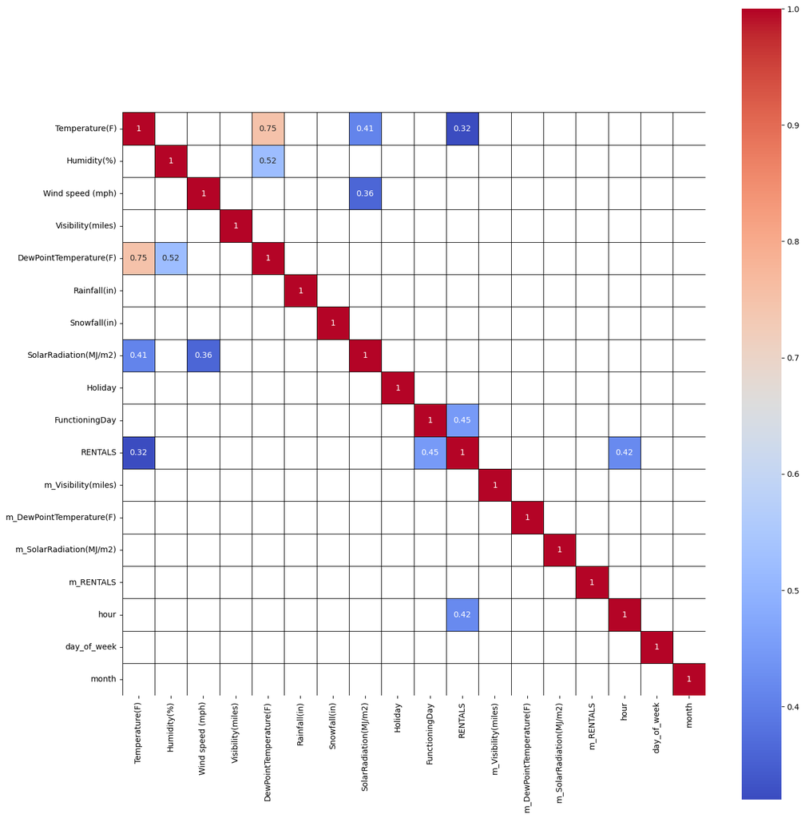

```python
# setting figure size
fig, ax = plt.subplots(figsize=(15,15))

#displaying only rows where at least 1 correlation >0.3 could be found
rows = ((numeric_rentals_corr > 0.3) & (numeric_rentals_corr != 1)).any(axis = 1)

# visualizing the correlation matrix, displaying only correlations >0.3
sns.heatmap(numeric_rentals_corr[numeric_rentals_corr>0.3],
            cmap        = 'coolwarm',
            square      = True,
            annot       = True,
            linecolor   = 'black',
            linewidths  = 0.5)


# layout and rendering
plt.tight_layout()
plt.show()
```

A correlation heatmap is as a great tool for discerning the relationships between various meteorological and temporal factors and their impact on bike rental frequency. The heatmap is restricted to display only statistically significant correlations, with a threshold set at 0.3 to focus on more relevant associations. For instance, the correlation between **Temperature(F)** and **DewPointTemperature(F)** is prominently positive, underlining the direct relationship between ambient temperature and moisture in the air, which can influence rental patterns. Additionally, a moderate positive correlation is observed between **RENTALS** and **hour**, indicating potential trends on bike rentals throughout the day.

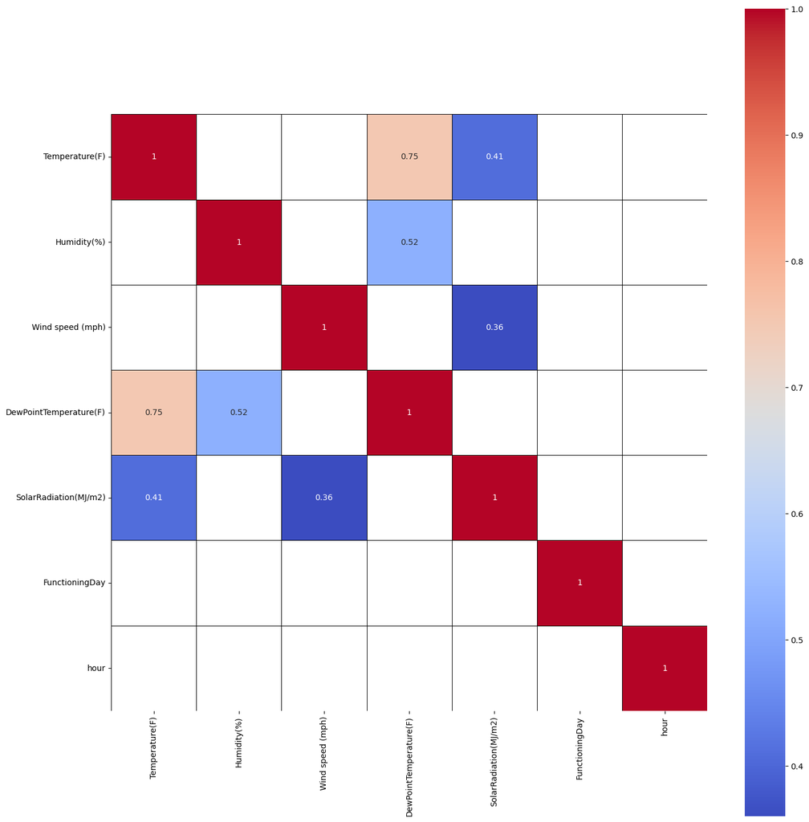

```python
# setting figure size
fig, ax = plt.subplots(figsize=(15,15))

#displaying only rows where at least 1 correlation >0.3 could be found
rows = ((numeric_rentals_corr > 0.3) & (numeric_rentals_corr != 1)).any(axis = 1)
numeric_rentals_corr = numeric_rentals_corr[rows].drop(['RENTALS'])
numeric_rentals_corr = numeric_rentals_corr.T[rows].drop(['RENTALS'])

# visualizing the correlation matrix, displaying only correlations >0.3
sns.heatmap(numeric_rentals_corr[numeric_rentals_corr>0.3],
            cmap = 'coolwarm',
            square = True,
            annot = True,
            linecolor = 'black',
            linewidths = 0.5)


# layout and rendering
plt.tight_layout()
plt.show()
```

The correlation heatmap presented here is designed to analyze the relationships between various weather and temporal variables independent of bike rental counts. By setting a threshold to highlight correlations above 0.3 and excluding **RENTALS**, the heatmap allows for a focused examination of how these variables correlate with each other, providing insights for feature selection in modeling without the influence of rental data.

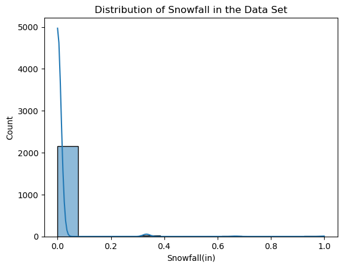

```python
# developing a histogram using HISTPLOT
sns.histplot(data=df_full, x='Snowfall(in)', kde=True)

# Adding title and axis labels
plt.title("Distribution of Snowfall in the Data Set")
plt.xlabel("Snowfall(in)")
plt.ylabel("Count")

# Displaying the histogram
plt.show()
```

The histogram represents the distribution of snowfall amounts in inches within the dataset. It shows that instances of snowfall are heavily concentrated at lower amounts, with the frequency drastically decreasing as the snowfall amount increases. This visualization emphasizes that significant snowfall is a relatively rare event in this dataset.

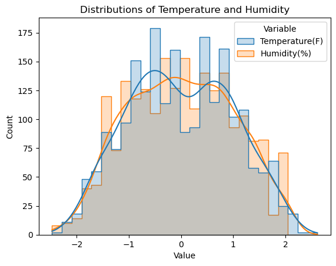

```python
# Example using df_train and comparing 'Temperature(F)' and 'Humidity(%)'
df_melted = df_full.melt(value_vars=['Temperature(F)', 'Humidity(%)'], var_name='Variable', value_name='Value')

sns.histplot(data=df_melted, x='Value', hue='Variable', kde=True, element='step', common_norm=False)

plt.title("Distributions of Temperature and Humidity")
plt.xlabel("Value")
plt.ylabel("Count")
plt.show()
```

The joint histogram delineates the frequency distributions for temperature and humidity, distinctly represented by blue and orange bars, respectively. This side-by-side portrayal is designed to uncover any associations or variances between these two meteorological variables, facilitating the derivation and comprehension of new variables from the existing data.

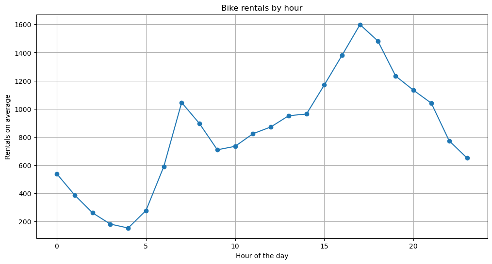

```python
# Group the data by 'hour' and calculate the mean rentals for each hour
hourly_rentals = df_full.groupby('hour')['RENTALS'].mean().reset_index()

# Create the line plot
plt.figure(figsize=(12,6))
plt.plot(hourly_rentals['hour'], hourly_rentals['RENTALS'], marker='o')
plt.title('Bike rentals by hour')
plt.xlabel('Hour of the day')
plt.ylabel('Rentals on average')
plt.grid(True)
plt.show()
```

The line graph portrays the average number of bike rentals at different hours throughout the day, based on data aggregated by hour. The plot shows two distinct peaks, suggesting higher rental activity during specific times, likely corresponding to morning and evening rush hours. The graph dips to its lowest point in the early hours, indicating minimal rental activity overnight. The 'Hour of the day' on the x-axis indicates the time, while the 'Rentals on average' on the y-axis quantifies the average rentals, providing a clear visualization of daily rental patterns. This temporal trend is valuable for understanding customer behavior and gives insights to the decision making when engineering new features.

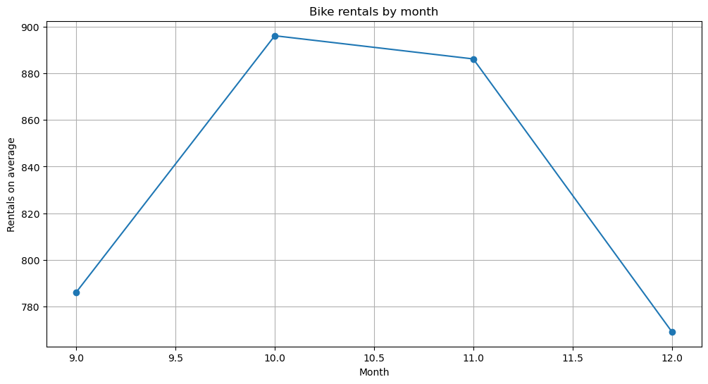

```python
# Group the data by 'mean' and calculate the mean rentals for each hour
monthly_rentals = df_full.groupby('month')['RENTALS'].mean().reset_index()

# Create the line plot
plt.figure(figsize=(12,6))
plt.plot(monthly_rentals['month'], monthly_rentals['RENTALS'], marker='o')
plt.title('Bike rentals by month')
plt.xlabel('Month')
plt.ylabel('Rentals on average')
plt.grid(True)
plt.show()
```

The plot indicates a rise in rentals peaking around October, maintaining a plateau through November, and then showing a sharp decline into December. This seasonal pattern reflects higher rental activity during the milder months, with a significant drop as the year ends, possibly due to colder weather. The 'Month' on the x-axis is marked from September (9) to December (12), while the 'Rentals on average' on the y-axis quantifies the mean number of rentals, revealing the fluctuating demand for bikes throughout these months. Understanding this trend is crucial for resource allocation, promotional planning, and anticipating changes in rental demand.

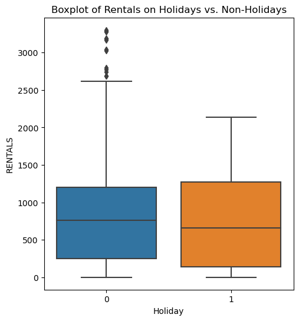

```python
# Boxplot for comparing rentals on Holidays vs. Non-Holidays
plt.figure(figsize=(12, 6))
plt.subplot(1, 2, 1)  # 1 row, 2 columns, 1st subplot
sns.boxplot(x='Holiday', y='RENTALS', data=df_full)
plt.title('Boxplot of Rentals on Holidays vs. Non-Holidays')

plt.show()
```

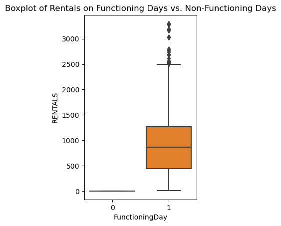

```python
# Boxplot for comparing rentals on Functioning Days vs. Non-Functioning Days
plt.subplot(1, 2, 2)  # 1 row, 2 columns, 2nd subplot
sns.boxplot(x='FunctioningDay', y='RENTALS', data=df_full)
plt.title('Boxplot of Rentals on Functioning Days vs. Non-Functioning Days')

plt.show()
```

This Boxplot shows that rentals are only occurring on functioning days, with a wide range of rental counts, indicated by the extensive spread of the box. The median value is well above zero, highlighting a consistent rental activity on these days. In contrast, the non-functioning days show no rentals. This visual comparison underscores the importance of operational status on rental volume.

### Feature Engineering

The first feature **OperatingHours** has been engineered by combining **FunctioningDay** with **hour** to represent the active hours during which the bike rental service operates. This multiplication effectively filters out non-operational hours, thus allowing for a more precise measurement of rental activity during actual service hours. The rationale behind creating this feature lies in the assumption that bike rentals are inherently linked to the service's operating schedule and that the demand is likely to be concentrated around specific hours when the service is available. This assumption is supported by the high correlations between these features and **RENTALS**

```python
# Feature 1: Operational Hours, multiplying 'FunctioningDay' with 'hour'
df_full['OperatingHours'] = df_full['FunctioningDay'] * df_full['hour']

# Now let's check the first few rows to see if the new feature was created correctly
print(df_full[['FunctioningDay', 'hour', 'OperatingHours']].head())
```

```
         FunctioningDay  hour  OperatingHours
ID
mb_1039               1     5               5
mb_1330               1     8               8
mb_551                1    21              21
mb_2103               0    14               0
mb_1430               1    12              12
```

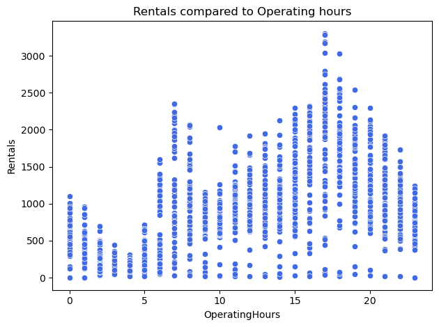

```python
# Scatterplot 'OperatingHours' to 'RENTALS'

sns.scatterplot(x       = df_full['OperatingHours'],
                y       = df_full['RENTALS'],
                color   = 'royalBlue')


# title and labels
plt.title(label   = 'Rentals compared to Operating hours')
plt.xlabel(xlabel = 'OperatingHours')
plt.ylabel(ylabel = 'Rentals')


# cleaning up layout and rendering visual
plt.tight_layout()
plt.show()
```

The plot supports this hypothesis, showing a denser aggregation of rentals during particular hours of the day. This pattern suggests peak rental times, potentially aligning with daily commuting patterns or leisure activities. The dispersion of data points at higher operating hours indicates variability in rental activity, which could be influenced by factors such as workday schedules, social events, or weather conditions. By visualizing this relationship, the plot highlights the potential of 'OperatingHours' as a predictor in demand-forecasting models and underscores the importance of considering operational timing in analyzing bike rental trends.

```python
# Feature 2: Peak hours

# Assuming df_full is your DataFrame and the 'hour' column has been properly set
# Apply the function to create new columns for morning and evening peak hour indicators
df_full['morning_peak'] = df_full['hour'].apply(lambda x: 1 if 7 <= x <= 9 else 0)
df_full['evening_peak'] = df_full['hour'].apply(lambda x: 1 if 16 <= x <= 18 else 0)

# Now let's create an enhanced feature that captures both morning and evening peaks
# This feature will have a value of 2 during hours that are peak in both morning and evening,
# a value of 1 if it's peak in either morning or evening, and 0 otherwise.
df_full['peak_hour'] = df_full['morning_peak'] + df_full['evening_peak']

# This will output the first few rows of the DataFrame for verification
print(df_full[['hour', 'morning_peak', 'evening_peak', 'peak_hour']].head())
```

```
         hour  morning_peak  evening_peak  peak_hour
ID
mb_1039     5             0             0          0
mb_1330     8             1             0          1
mb_551     21             0             0          0
mb_2103    14             0             0          0
mb_1430    12             0             0          0
```

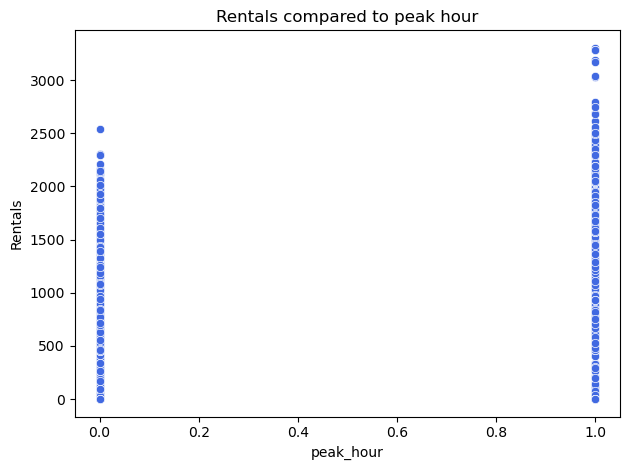

```python
# Scatterplot 'peak_hour' to 'RENTALS'

sns.scatterplot(x       = df_full['peak_hour'],
                y       = df_full['RENTALS'],
                color   = 'royalBlue')


# title and labels
plt.title(label   = 'Rentals compared to peak hour')
plt.xlabel(xlabel = 'peak_hour')
plt.ylabel(ylabel = 'Rentals')


# cleaning up layout and rendering visual
plt.tight_layout()
plt.show()
```

The scatterplot contrasting 'peak_hour' with rental numbers delineates their correlation. The concentration of data points at the 'peak_hour' values of 1 showcases significant rental volumes during the established peak times. The spread of rental data during these peak hours points to a variation in rental numbers, potentially due to daily shifts in commuting patterns and other conditions.

In our analysis, the 'Comfort_Index' feature has been devised to quantify the perceived weather comfort based on a combination of meteorological factors. These factors include temperature, dew point temperature, solar radiation, humidity, and wind speed, each weighted according to its correlation strength and perceived impact on comfort. Positive correlations, such as temperature and dew point temperature, are assigned positive weights, while negative correlations, such as humidity, are assigned negative weights. The resulting 'Comfort_Index' serves as a composite measure of weather comfort, reflecting both favorable and unfavorable weather conditions that could influence bike rental behavior.

```python
# Feature 3: Weather comfort Index

# Weights are assigned based on the correlation strength and perceived impact on comfort
weight_temp = 0.4  # Temperature has a strong positive correlation
weight_dewpoint = 0.3  # DewPointTemperature has a positive correlation
weight_solar = 0.2  # SolarRadiation has a moderate positive correlation
weight_humidity = -0.1  # Humidity has a negative correlation, so we assign a negative weight
weight_wind = 0.1  # Wind speed has a positive but lower correlation compared to Temperature

df_full['Comfort_Index'] = (
    df_full['Temperature(F)'] * weight_temp +
    df_full['DewPointTemperature(F)'] * weight_dewpoint +
    df_full['SolarRadiation(MJ/m2)'] * weight_solar +
    df_full['Humidity(%)'] * weight_humidity +  # Note the negative sign to account for the negative correlation
    df_full['Wind speed (mph)'] * weight_wind
)
# Checking results
df_full[['Comfort_Index']].head()
```

| ID | Comfort_Index |
| --- | --- |
| mb_1039 | -0.316339 |
| mb_1330 | -0.174607 |
| mb_551 | -0.169698 |
| mb_2103 | 0.971170 |
| mb_1430 | -0.178090 |

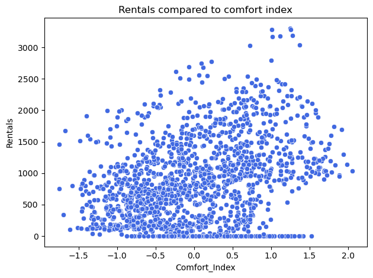

```python
# Scatterplot 'Comfort_index' to 'RENTALS'

sns.scatterplot(x       = df_full['Comfort_Index'],
                y       = df_full['RENTALS'],
                color   = 'royalBlue')


# title and labels
plt.title(label   = 'Rentals compared to comfort index')
plt.xlabel(xlabel = 'Comfort_Index')
plt.ylabel(ylabel = 'Rentals')


# cleaning up layout and rendering visual
plt.tight_layout()
plt.show()
```

The scatterplot mapping 'Comfort_Index' against bike rentals offers insights into the relationship between weather comfort and rental activity. Points clustered at higher 'Comfort_Index' values indicate higher rental counts during more comfortable weather conditions, while points at lower 'Comfort_Index' values suggest reduced rental activity during less favorable weather. The dispersion of data points across the range of comfort indices underscores the variability in rental patterns, potentially influenced by factors such as seasonal variations and user preferences. This visualization underscores the potential of the 'Comfort_Index' feature in capturing the nuanced relationship between weather conditions and bike rental demand, thus helping in predictive modeling and operational decision-making.

```python
# Select only numeric columns for the correlation matrix
numeric_rentals_0 = df_full.select_dtypes(include=[np.number])

# instantiating a correlation matrix
numeric_rentals_corr_0 = numeric_rentals_0.corr().round(2)

# filtering results to show correlations with RENTALS
numeric_rentals_corr_0.loc[ : , 'RENTALS'].round(decimals = 2).sort_values(ascending = False)
```

```
RENTALS                     1.00
OperatingHours              0.62
FunctioningDay              0.45
hour                        0.42
evening_peak                0.39
Temperature(F)              0.32
peak_hour                   0.32
Comfort_Index               0.30
SolarRadiation(MJ/m2)       0.20
Wind speed (mph)            0.19
day_of_week                 0.10
DewPointTemperature(F)      0.03
morning_peak                0.03
month                      -0.01
Visibility(miles)          -0.01
Holiday                    -0.03
m_DewPointTemperature(F)   -0.03
m_SolarRadiation(MJ/m2)    -0.04
Snowfall(in)               -0.09
m_Visibility(miles)        -0.11
Rainfall(in)               -0.15
Humidity(%)                -0.40
m_RENTALS                    NaN
Name: RENTALS, dtype: float64
```

```python
df_full.info() # Check datatypes to ensure they are appropriate for modeling
```

```
<class 'pandas.core.frame.DataFrame'>
Index: 2184 entries, mb_1039 to mb_1225
Data columns (total 24 columns):
 #   Column                    Non-Null Count  Dtype
---  ------                    --------------  -----
 0   Temperature(F)            2184 non-null   float64
 1   Humidity(%)               2184 non-null   float64
 2   Wind speed (mph)          2184 non-null   float64
 3   Visibility(miles)         2184 non-null   float64
 4   DewPointTemperature(F)    2184 non-null   float64
 5   Rainfall(in)              2184 non-null   float64
 6   Snowfall(in)              2184 non-null   float64
 7   SolarRadiation(MJ/m2)     2184 non-null   float64
 8   Holiday                   2184 non-null   int64
 9   FunctioningDay            2184 non-null   int64
```

[output cut: 16 more lines]

```python
df_full.head(n=10)
```

| ID | Temperature(F) | Humidity(%) | Wind speed (mph) | Visibility(miles) | DewPointTemperature(F) | Rainfall(in) | Snowfall(in) | SolarRadiation(MJ/m2) | Holiday | FunctioningDay | RENTALS | set | m_Visibility(miles) | m_DewPointTemperature(F) | m_SolarRadiation(MJ/m2) | m_RENTALS | hour | day_of_week | month | OperatingHours | morning_peak | evening_peak | peak_hour | Comfort_Index |
| --- | --- | --- | --- | --- | --- | --- | --- | --- | --- | --- | --- | --- | --- | --- | --- | --- | --- | --- | --- | --- | --- | --- | --- | --- |
| mb_1039 | -0.419144 | 1.165364 | 0.031250 | 0.233871 | 0.316730 | 0.0 | 0.0 | -0.651443 | 0 | 1 | 519.0 | Not Kaggle | 0 | 0 | 0 | 0 | 5 | 5 | 10 | 5 | 0 | 0 | 0 | -0.316339 |
| mb_1330 | -0.496912 | -0.333392 | 0.171875 | 0.943548 | -0.496159 | 0.0 | 0.0 | 0.612391 | 0 | 1 | 1251.0 | Not Kaggle | 1 | 0 | 0 | 0 | 8 | 3 | 10 | 8 | 1 | 0 | 1 | -0.174607 |
| mb_551 | -0.108071 | -0.547500 | 0.195312 | 0.274194 | -0.234873 | 0.0 | 0.0 | -0.651443 | 0 | 1 | 1685.0 | Not Kaggle | 0 | 0 | 0 | 0 | 21 | 5 | 9 | 21 | 0 | 0 | 0 | -0.169698 |
| mb_2103 | 0.902916 | -1.457458 | 0.765625 | 1.000000 | -0.242131 | 0.0 | 0.0 | 2.301674 | 0 | 0 | 0.0 | Not Kaggle | 0 | 0 | 0 | 0 | 14 | 1 | 12 | 0 | 0 | 0 | 0 | 0.971170 |
| mb_1430 | -0.341375 | -2.099782 | 0.226562 | 0.870968 | -2.114677 | 0.0 | 0.0 | 1.801145 | 0 | 1 | 814.0 | Not Kaggle | 0 | 0 | 0 | 0 | 12 | 0 | 10 | 12 | 0 | 0 | 0 | -0.178090 |
| mb_781 | -0.574680 | 0.683621 | 0.351562 | 0.943548 | 0.019154 | 0.0 | 0.0 | -0.276047 | 0 | 1 | 731.0 | Not Kaggle | 0 | 0 | 0 | 0 | 11 | 1 | 10 | 11 | 0 | 0 | 0 | -0.312541 |
| mb_1642 | -2.285581 | -1.403931 | 0.156250 | 0.774194 | -2.782407 | 0.0 | 0.0 | 0.049297 | 0 | 1 | 800.0 | Not Kaggle | 0 | 0 | 0 | 0 | 9 | 3 | 11 | 9 | 1 | 0 | 1 | -1.583077 |
| mb_870 | 1.136221 | 0.576567 | 0.210938 | 0.653226 | 1.202197 | 0.0 | 0.0 | -0.651443 | 0 | 1 | 260.0 | Not Kaggle | 0 | 0 | 0 | 0 | 4 | 5 | 10 | 4 | 0 | 0 | 0 | 0.648296 |
| mb_1483 | 0.280770 | -0.975716 | 0.242188 | 1.000000 | -0.351000 | 0.0 | 0.0 | -0.576364 | 0 | 1 | 1699.0 | Not Kaggle | 0 | 0 | 0 | 0 | 18 | 3 | 11 | 18 | 0 | 1 | 1 | 0.013526 |
| mb_092 | 2.069439 | -0.279865 | 0.265625 | 1.000000 | 1.507030 | 0.0 | 0.0 | -0.588877 | 0 | 1 | 2085.0 | Not Kaggle | 0 | 0 | 0 | 0 | 18 | 0 | 9 | 18 | 0 | 1 | 1 | 1.216658 |

## Part III: Data Partitioning

```python
# Split the data back into the original training and testing sets
df_training = df_full[df_full['set'] != 'Kaggle']
kaggle_data = df_full[df_full['set'] == 'Kaggle']

# Drop the 'set' column as it is no longer needed
df_training.drop('set', axis=1, inplace=True)
kaggle_data.drop('set', axis=1, inplace=True)

# Separate features and target variable for the training data
x_train = df_training.drop('RENTALS', axis=1)
y_train = df_training['RENTALS']

# Since the test set does not contain the y_variable, all its columns are features
x_kaggle = kaggle_data.drop('RENTALS', axis=1, errors='ignore')  # Using errors='ignore' in case 'RENTALS' is not present in kaggle_data
```

```python
df_training.head(n=10) # Check the head of training set
```

| ID | Temperature(F) | Humidity(%) | Wind speed (mph) | Visibility(miles) | DewPointTemperature(F) | Rainfall(in) | Snowfall(in) | SolarRadiation(MJ/m2) | Holiday | FunctioningDay | RENTALS | m_Visibility(miles) | m_DewPointTemperature(F) | m_SolarRadiation(MJ/m2) | m_RENTALS | hour | day_of_week | month | OperatingHours | morning_peak | evening_peak | peak_hour | Comfort_Index |
| --- | --- | --- | --- | --- | --- | --- | --- | --- | --- | --- | --- | --- | --- | --- | --- | --- | --- | --- | --- | --- | --- | --- | --- |
| mb_1039 | -0.419144 | 1.165364 | 0.031250 | 0.233871 | 0.316730 | 0.0 | 0.0 | -0.651443 | 0 | 1 | 519.0 | 0 | 0 | 0 | 0 | 5 | 5 | 10 | 5 | 0 | 0 | 0 | -0.316339 |
| mb_1330 | -0.496912 | -0.333392 | 0.171875 | 0.943548 | -0.496159 | 0.0 | 0.0 | 0.612391 | 0 | 1 | 1251.0 | 1 | 0 | 0 | 0 | 8 | 3 | 10 | 8 | 1 | 0 | 1 | -0.174607 |
| mb_551 | -0.108071 | -0.547500 | 0.195312 | 0.274194 | -0.234873 | 0.0 | 0.0 | -0.651443 | 0 | 1 | 1685.0 | 0 | 0 | 0 | 0 | 21 | 5 | 9 | 21 | 0 | 0 | 0 | -0.169698 |
| mb_2103 | 0.902916 | -1.457458 | 0.765625 | 1.000000 | -0.242131 | 0.0 | 0.0 | 2.301674 | 0 | 0 | 0.0 | 0 | 0 | 0 | 0 | 14 | 1 | 12 | 0 | 0 | 0 | 0 | 0.971170 |
| mb_1430 | -0.341375 | -2.099782 | 0.226562 | 0.870968 | -2.114677 | 0.0 | 0.0 | 1.801145 | 0 | 1 | 814.0 | 0 | 0 | 0 | 0 | 12 | 0 | 10 | 12 | 0 | 0 | 0 | -0.178090 |
| mb_781 | -0.574680 | 0.683621 | 0.351562 | 0.943548 | 0.019154 | 0.0 | 0.0 | -0.276047 | 0 | 1 | 731.0 | 0 | 0 | 0 | 0 | 11 | 1 | 10 | 11 | 0 | 0 | 0 | -0.312541 |
| mb_1642 | -2.285581 | -1.403931 | 0.156250 | 0.774194 | -2.782407 | 0.0 | 0.0 | 0.049297 | 0 | 1 | 800.0 | 0 | 0 | 0 | 0 | 9 | 3 | 11 | 9 | 1 | 0 | 1 | -1.583077 |
| mb_870 | 1.136221 | 0.576567 | 0.210938 | 0.653226 | 1.202197 | 0.0 | 0.0 | -0.651443 | 0 | 1 | 260.0 | 0 | 0 | 0 | 0 | 4 | 5 | 10 | 4 | 0 | 0 | 0 | 0.648296 |
| mb_1483 | 0.280770 | -0.975716 | 0.242188 | 1.000000 | -0.351000 | 0.0 | 0.0 | -0.576364 | 0 | 1 | 1699.0 | 0 | 0 | 0 | 0 | 18 | 3 | 11 | 18 | 0 | 1 | 1 | 0.013526 |
| mb_092 | 2.069439 | -0.279865 | 0.265625 | 1.000000 | 1.507030 | 0.0 | 0.0 | -0.588877 | 0 | 1 | 2085.0 | 0 | 0 | 0 | 0 | 18 | 0 | 9 | 18 | 0 | 1 | 1 | 1.216658 |

```python
# Select only numeric columns for the correlation matrix
numeric_rentals_1 = df_training.select_dtypes(include=[np.number])

# instantiating a correlation matrix
numeric_rentals_corr_1 = numeric_rentals_1.corr().round(2)

# filtering results to show correlations with RENTALS
numeric_rentals_corr_1.loc[ : , 'RENTALS'].round(decimals = 2).sort_values(ascending = False)
```

```
RENTALS                     1.00
OperatingHours              0.62
FunctioningDay              0.45
hour                        0.42
evening_peak                0.39
Temperature(F)              0.32
peak_hour                   0.32
Comfort_Index               0.30
SolarRadiation(MJ/m2)       0.20
Wind speed (mph)            0.19
day_of_week                 0.10
DewPointTemperature(F)      0.03
morning_peak                0.03
month                      -0.01
Visibility(miles)          -0.01
Holiday                    -0.03
m_DewPointTemperature(F)   -0.03
m_SolarRadiation(MJ/m2)    -0.04
Snowfall(in)               -0.09
m_Visibility(miles)        -0.11
Rainfall(in)               -0.15
Humidity(%)                -0.40
m_RENTALS                    NaN
Name: RENTALS, dtype: float64
```

### Train-Test Split

In the candidate model development and final model selection phase, I embarked on a comprehensive process to identify the most suitable predictive model for the bike rental prediction analysis. Initially, I selected a set of predictor features, including 'OperatingHours', 'FunctioningDay', 'hour', 'evening_peak', 'Temperature(F)', 'peak_hour', 'Comfort_Index', 'SolarRadiation(MJ/m2)', 'Wind speed (mph)', 'Snowfall(in)', 'Rainfall(in)', and 'Humidity(%)'. These features were chosen based on their strong correlations with the target variable 'RENTALS', ensuring that the model captures essential factors influencing rentals.

```python
# Choose x_features based on how they correlate with 'RENTALS'

x_features = [ 'OperatingHours', 'FunctioningDay', 'hour', 'evening_peak',
              'Temperature(F)', 'peak_hour', 'Comfort_Index',
               'SolarRadiation(MJ/m2)', 'Wind speed (mph)', 'Snowfall(in)', 'Rainfall(in)', 'Humidity(%)' ]
```

```python
# prepping data for train-test split
y_data = df_training[y_variable]


# removing non-numeric columns and missing values
x_data = df_training[x_features].copy().select_dtypes(include=[int, float]).dropna(axis = 1)


# storing remaining x_features after the step above
x_features = list(x_data.columns)


# train-test split (to validate the model)
x_train, x_test, y_train, y_test = train_test_split(x_data,
                                                    y_data,
                                                    test_size    = 0.25,
                                                    random_state = 702 )


# results of train-test split
print(f"""
Original Dataset Dimensions
---------------------------
Observations (Rows): {df_training.shape[0]}
Features  (Columns): {df_training.shape[1]}


Training Data (X-side)
----------------------
Observations (Rows): {x_train.shape[0]}
Features  (Columns): {x_train.shape[1]}


Training Data (y-side)
----------------------
Feature Name:        {y_train.name}
Observations (Rows): {y_train.shape[0]}


Testing Data (X-side)
---------------------
Observations (Rows): {x_test.shape[0]}
Features  (Columns): {x_test.shape[1]}


Testing Data (y-side)
---------------------
Feature Name:        {y_test.name}
Observations (Rows): {y_test.shape[0]}""")
```

```
Original Dataset Dimensions
---------------------------
Observations (Rows): 1638
Features  (Columns): 23


Training Data (X-side)
----------------------
Observations (Rows): 1228
Features  (Columns): 12


Training Data (y-side)
----------------------
Feature Name:        RENTALS
Observations (Rows): 1228


Testing Data (X-side)
---------------------
Observations (Rows): 410
Features  (Columns): 12


Testing Data (y-side)
---------------------
Feature Name:        RENTALS
Observations (Rows): 410
```

## Part III: Candidate Modeling

Given their promising performance, I have decided to further refine the KNN, Lasso, and Ridge regression models through hyperparameter tuning.

```python
# Naming the model
model_name = 'OLS Linear Regression'

# Model type
model = sklearn.linear_model.LinearRegression()

## ########################### ##
## DON'T CHANGE THE CODE BELOW ##
## ########################### ##

# FITTING to the training data
model_fit = model.fit(x_train, y_train)

# PREDICTING on new data
model_pred = model.predict(x_test)

# SCORING the results
model_train_score = model.score(x_train, y_train).round(4)
model_test_score  = model.score(x_test, y_test).round(4)
model_gap         = abs(model_train_score - model_test_score).round(4)

# Dynamically printing results
model_summary =  f"""\
Model Name:     {model_name}
Train Score:    {model_train_score}
Test Score:     {model_test_score}
Train-Test Gap: {model_gap}
"""

print(model_summary)
```

```
Model Name:     OLS Linear Regression
Train Score:    0.6591
Test Score:     0.6196
Train-Test Gap: 0.0395
```

```python
# Organizing residuals
model_residuals = {
    "True": y_test,
    "Predicted": model_pred
}

# Converting residuals into DataFrame
model_resid_df = pd.DataFrame(data=model_residuals)

# Calculating residuals
model_resid_df['Residuals'] = model_resid_df['True'] - model_resid_df['Predicted']

# Checking results
print(model_resid_df.head(n=5))
```

```
           True    Predicted   Residuals
ID
mb_1509   908.0  1002.039938  -94.039938
mb_559    131.0   241.639337 -110.639337
mb_040   1208.0  1153.813364   54.186636
mb_1346   291.0   287.481612    3.518388
mb_1463  1433.0  1147.679345  285.320655
```

The OLS Linear Regression model achieved a training score of 0.6591 and a test score of 0.6196, indicating a relatively balanced performance. However, there is a noticeable gap of 0.0395 between the training and test scores, suggesting potential overfitting.

While this model provides a nice baseline, the moderate gap between training and test scores indicates the need for further exploration to improve generalization performance.

```python
# Naming the model
model_name = 'Lasso Regression'

# Model type
model = sklearn.linear_model.Lasso(alpha=1.0, random_state=42)  # You can adjust the alpha parameter as needed

## ########################### ##
## DON'T CHANGE THE CODE BELOW ##
## ########################### ##

# FITTING to the training data
model_fit = model.fit(x_train, y_train)

# PREDICTING on new data
model_pred = model.predict(x_test)

# SCORING the results
model_train_score = model.score(x_train, y_train).round(4)
model_test_score  = model.score(x_test, y_test).round(4)
model_gap         = abs(model_train_score - model_test_score).round(4)

# Dynamically printing results
model_summary =  f"""\
Model Name:     {model_name}
Train Score:    {model_train_score}
Test Score:     {model_test_score}
Train-Test Gap: {model_gap}
"""

print(model_summary)
```

```
Model Name:     Lasso Regression
Train Score:    0.6578
Test Score:     0.6138
Train-Test Gap: 0.044
```

```python
## Residual Analysis ##

# Organizing residuals
model_residuals = {
    "True": y_test,
    "Predicted": model_pred
}

# Converting residuals into DataFrame
model_resid_df = pd.DataFrame(data=model_residuals)

# Calculating residuals
model_resid_df['Residuals'] = model_resid_df['True'] - model_resid_df['Predicted']

# Checking results
print(model_resid_df.head(n=5))
```

```
           True    Predicted   Residuals
ID
mb_1509   908.0  1003.213330  -95.213330
mb_559    131.0   270.387417 -139.387417
mb_040   1208.0  1168.709622   39.290378
mb_1346   291.0   280.414220   10.585780
mb_1463  1433.0  1136.088146  296.911854
```

The Lasso Regression model yielded a training score of 0.6578 and a test score of 0.6138, with a gap of 0.044 between them. Despite slightly lower scores compared to OLS, the model demonstrates consistent performance.

```python
# Naming the model
model_name = 'Ridge Regression'

# Model type
model = sklearn.linear_model.Ridge(alpha=1.0, random_state=42)  # alpha can be adjusted as needed

## ########################### ##
## DON'T CHANGE THE CODE BELOW ##
## ########################### ##

# FITTING to the training data
model_fit = model.fit(x_train, y_train)

# PREDICTING on new data
model_pred = model.predict(x_test)

# SCORING the results
model_train_score = model.score(x_train, y_train).round(4)
model_test_score  = model.score(x_test, y_test).round(4)
model_gap         = abs(model_train_score - model_test_score).round(4)

# Dynamically printing results
model_summary =  f"""\
Model Name:     {model_name}
Train Score:    {model_train_score}
Test Score:     {model_test_score}
Train-Test Gap: {model_gap}
"""

print(model_summary)
```

```
Model Name:     Ridge Regression
Train Score:    0.6589
Test Score:     0.6171
Train-Test Gap: 0.0418
```

```python
## Residual Analysis ##

# Organizing residuals
model_residuals = {
    "True": y_test,
    "Predicted": model_pred
}

# Converting residuals into DataFrame
model_resid_df = pd.DataFrame(data=model_residuals)

# Calculating residuals
model_resid_df['Residuals'] = model_resid_df['True'] - model_resid_df['Predicted']

# Checking results
print(model_resid_df.head(n=5))
```

```
           True    Predicted   Residuals
ID
mb_1509   908.0  1004.720846  -96.720846
mb_559    131.0   252.028749 -121.028749
mb_040   1208.0  1153.046723   54.953277
mb_1346   291.0   287.898538    3.101462
mb_1463  1433.0  1143.093536  289.906464
```

Ridge Regression achieved a training score of 0.6589 and a test score of 0.6171, with a gap of 0.0418 between the two. This performance indicates stable and relatively balanced generalization. I chose Ridge Regression for further hyperparameter tuning because of its ability to maintain feature relevance while addressing multicollinearity, which is crucial for improving predictive accuracy.

```python
# Naming the model
model_name = 'Elastic Net Regression'

# Model type: Setting up SGDRegressor for Elastic Net
# alpha: Regularization strength
# l1_ratio: The Elastic Net mixing parameter, with 0 <= l1_ratio <= 1.
# l1_ratio=0 corresponds to L2 penalty, l1_ratio=1 to L1. Values between 0 and 1 allow for a combination of both.
model = SGDRegressor(penalty='elasticnet', alpha=0.0001, l1_ratio=0.15, max_iter=1000, tol=1e-3, random_state=42)

## ########################### ##
## DON'T CHANGE THE CODE BELOW ##
## ########################### ##

# FITTING to the training data
model_fit = model.fit(x_train, y_train)

# PREDICTING on new data
model_pred = model.predict(x_test)

# Calculating R^2 score manually for both train and test sets
model_train_score = model.score(x_train, y_train).round(4)
model_test_score = model.score(x_test, y_test).round(4)

# Calculating the Train-Test Gap
model_gap = abs(model_train_score - model_test_score).round(4)

# Dynamically printing results
model_summary =  f"""\
Model Name:     {model_name}
Train Score:    {model_train_score}
Test Score:     {model_test_score}
Train-Test Gap: {model_gap}
"""

print(model_summary)
```

```
Model Name:     Elastic Net Regression
Train Score:    0.6234
Test Score:     0.5749
Train-Test Gap: 0.0485
```

```python
## Residual Analysis ##

# Organizing residuals
model_residuals = {
    "True": y_test,
    "Predicted": model_pred
}

# Converting residuals into DataFrame
model_resid_df = pd.DataFrame(data=model_residuals)

# Calculating residuals
model_resid_df['Residuals'] = model_resid_df['True'] - model_resid_df['Predicted']

# Checking results
print(model_resid_df.head(n=5))
```

```
           True    Predicted   Residuals
ID
mb_1509   908.0  1165.365131 -257.365131
mb_559    131.0   336.004181 -205.004181
mb_040   1208.0  1286.435122  -78.435122
mb_1346   291.0   282.856199    8.143801
mb_1463  1433.0  1306.446473  126.553527
```

The Elastic Net Regression model exhibited a training score of 0.6234 and a test score of 0.5749, with a relatively consistent gap of 0.0485 between the two. Despite resulting the lowest scores among the models, Elastic Net Regression demonstrates fair generalization performance. Despite its modest performance, Elastic Net Regression remains a viable option for predictive modeling tasks requiring a balance between accuracy and feature interpretability. However due to it's weaker performance, I will drop it from the next stage.

```python
# Naming the model
model_name = 'K-Nearest Neighbors Regression'

# Model type: Initializing KNeighborsRegressor
# n_neighbors: Number of neighbors to use by default for queries
model = KNeighborsRegressor(n_neighbors=6)  # The default value is 5, but you can adjust it based on your needs

## ########################### ##
## DON'T CHANGE THE CODE BELOW ##
## ########################### ##

# FITTING to the training data
model_fit = model.fit(x_train, y_train)

# PREDICTING on new data
model_pred = model.predict(x_test)

# SCORING the results - calculating R^2 score manually for both train and test sets
model_train_score = model.score(x_train, y_train).round(4)
model_test_score = model.score(x_test, y_test).round(4)

# Calculating the Train-Test Gap
model_gap = abs(model_train_score - model_test_score).round(4)

# Dynamically printing results
model_summary =  f"""\
Model Name:     {model_name}
Train Score:    {model_train_score}
Test Score:     {model_test_score}
Train-Test Gap: {model_gap}
"""

print(model_summary)
```

```
Model Name:     K-Nearest Neighbors Regression
Train Score:    0.8391
Test Score:     0.7302
Train-Test Gap: 0.1089
```

```python
## Residual Analysis ##

# Organizing residuals
model_residuals = {
    "True": y_test,
    "Predicted": model_pred
}

# Converting residuals into DataFrame
model_resid_df = pd.DataFrame(data=model_residuals)

# Calculating residuals
model_resid_df['Residuals'] = model_resid_df['True'] - model_resid_df['Predicted']

# Checking results
print(model_resid_df.head(n=5))
```

```
           True    Predicted   Residuals
ID
mb_1509   908.0   872.333333   35.666667
mb_559    131.0   379.666667 -248.666667
mb_040   1208.0  1429.500000 -221.500000
mb_1346   291.0   507.500000 -216.500000
mb_1463  1433.0  1244.833333  188.166667
```

KNN Regression achieved a training score of 0.8391 and a test score of 0.7302, with a considerable gap of 0.1089 between them. KNN demonstrates superior predictive performance but exhibits a significant gap between training and test scores, suggesting potential overfitting. However due to the performance I chose it to the hyperparameter tuning stage.

```python
# Naming the model
model_name = 'Decision Tree Regressor'

# Model type: Initializing DecisionTreeRegressor
model = tree.DecisionTreeRegressor()  # Using tree.DecisionTreeRegressor()

## ########################### ##
## DON'T CHANGE THE CODE BELOW ##
## ########################### ##

# FITTING to the training data
model_fit = model.fit(x_train, y_train)

# PREDICTING on new data
model_pred = model.predict(x_test)

# SCORING the results - calculating R^2 score manually for both train and test sets
model_train_score = model.score(x_train, y_train).round(4)
model_test_score = model.score(x_test, y_test).round(4)

# Calculating the Train-Test Gap
model_gap = abs(model_train_score - model_test_score).round(4)

# Dynamically printing results
model_summary =  f"""\
Model Name:     {model_name}
Train Score:    {model_train_score}
Test Score:     {model_test_score}
Train-Test Gap: {model_gap}
"""

print(model_summary)
```

```
Model Name:     Decision Tree Regressor
Train Score:    1.0
Test Score:     0.6401
Train-Test Gap: 0.3599
```

```python
## Residual Analysis ##

# Organizing residuals
model_residuals = {
    "True": y_test,
    "Predicted": model_pred
}

# Converting residuals into DataFrame
model_resid_df = pd.DataFrame(data=model_residuals)

# Calculating residuals
model_resid_df['Residuals'] = model_resid_df['True'] - model_resid_df['Predicted']

# Checking results
print(model_resid_df.head(n=5))
```

```
           True  Predicted  Residuals
ID
mb_1509   908.0     1146.0     -238.0
mb_559    131.0       41.0       90.0
mb_040   1208.0     2124.0     -916.0
mb_1346   291.0      496.0     -205.0
mb_1463  1433.0     1535.0     -102.0
```

### Model Results

```
Coefficients: [  37.99325487  550.84684731   -8.14476216   63.86511746  167.34279624
  410.38332282   73.55169772  -54.04091602  -96.49421562 -107.84370438
 -783.57655632 -175.6952232 ]
Intercept: -33.98128965964804
```

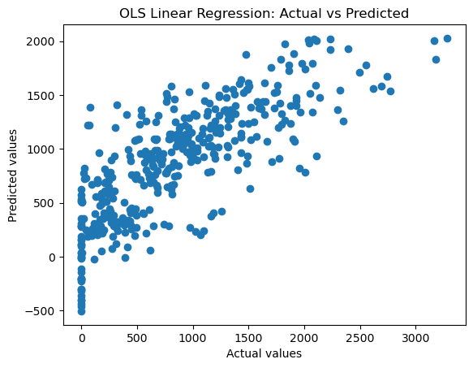

```python
# Fit the model
ols_model = LinearRegression()
ols_model.fit(x_train, y_train)

# Coefficients
print("Coefficients:", ols_model.coef_)
print("Intercept:", ols_model.intercept_)

# Predictions for visualization
predictions = ols_model.predict(x_test)

# Scatter plot of actual vs. predicted values
plt.scatter(y_test, predictions)
plt.xlabel('Actual values')
plt.ylabel('Predicted values')
plt.title('OLS Linear Regression: Actual vs Predicted')
plt.show()
```

The OLS Linear Regression model's coefficients indicate varying degrees of influence on bike rental counts, with positive values increasing predicted rentals and negative ones decreasing them. The second feature's large positive coefficient suggests it is a strong predictor of increased bike rentals, while another feature with a large negative coefficient greatly reduces the predicted rentals. The intercept implies the predicted count when all features are zero.

The scatter plot of actual versus predicted values indicates the model's predictive trends but also reveals inaccuracies, particularly in overestimating lower actual values and underestimating higher ones. This discrepancy suggests the model's limitations in capturing the true complexity of the data.

```
Coefficients: [  41.01670979  506.73156141  -11.11668295   46.71272289  215.32321204
  409.476365      0.          -43.26388601  -54.59082154   -0.
 -393.11142948 -176.29550545]
Intercept: -1.5703450735209117
```

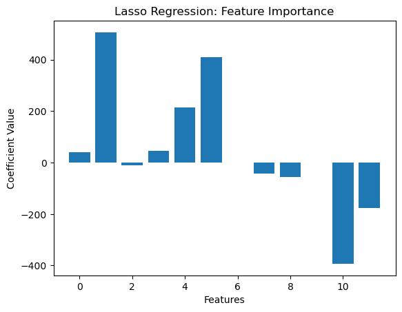

```python
# Fit the model
lasso_model = Lasso(alpha=1.0)  # alpha is a hyperparameter you can tune
lasso_model.fit(x_train, y_train)

# Coefficients
print("Coefficients:", lasso_model.coef_)
print("Intercept:", lasso_model.intercept_)

# Feature importance visualization
plt.bar(range(len(lasso_model.coef_)), lasso_model.coef_)
plt.xlabel('Features')
plt.ylabel('Coefficient Value')
plt.title('Lasso Regression: Feature Importance')
plt.show()
```

The bar chart illustrates the impact of each feature on the model's predictions. Features with taller bars are more influential, with positive values indicating a direct relationship with bike rentals and negative values an inverse one. The chart also reveals that Lasso has identified certain features as non-influential by reducing their coefficients to zero, thereby simplifying the model and potentially improving interpretability. This visualization is crucial for understanding which features contribute most to the model's predictions and can guide further data collection and feature engineering efforts.

```
Coefficients: [  39.51283727  530.00409249   -9.70463284   64.73245537  161.32698379
  407.03350647   82.98949079  -56.7644657  -101.12894385 -100.65095009
 -579.03260464 -180.00061956]
Intercept: -12.725235356910503
```

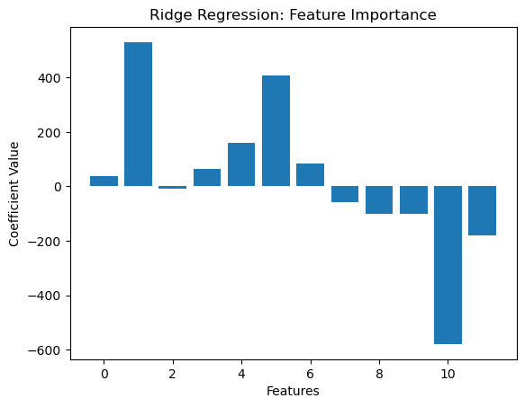

```python
# Fit the model
ridge_model = Ridge(alpha=1.0)  # alpha is a hyperparameter you can tune
ridge_model.fit(x_train, y_train)

# Coefficients
print("Coefficients:", ridge_model.coef_)
print("Intercept:", ridge_model.intercept_)

# Feature importance visualization
plt.bar(range(len(ridge_model.coef_)), ridge_model.coef_)
plt.xlabel('Features')
plt.ylabel('Coefficient Value')
plt.title('Ridge Regression: Feature Importance')
plt.show()
```

The Ridge Regression model assigns a weight to each feature, representing its relative importance in the prediction of bike rental counts. The feature importance bar chart for Ridge Regression shows that feature 1 is given the highest positive coefficient, indicating a strong positive effect on bike rentals. Conversely, feature 10 has a large negative coefficient, suggesting it significantly decreases the predicted bike rentals. None of the coefficients are shrunk to zero, which is typical for Ridge Regression as it does not inherently perform feature selection like Lasso does.

The visualized coefficient values illustrate the magnitude and direction of each feature's impact on the model's predictions. Taller bars signify greater importance, with the direction of the bar (upward or downward) indicating a positive or negative relationship with the target variable. This chart highlights that Ridge Regression considers all provided features to some extent, as it tends to shrink coefficients towards zero but not exactly to zero.

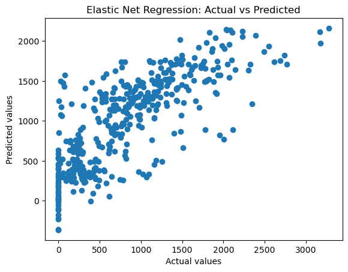

```python
# Fit the model
elastic_net_model = SGDRegressor(penalty='elasticnet', alpha=0.1, l1_ratio=0.5)
elastic_net_model.fit(x_train, y_train)

predictions_enet = elastic_net_model.predict(x_test)

# Plotting actual vs. predicted values can be done similarly to the OLS example
plt.scatter(y_test, predictions_enet)
plt.xlabel('Actual values')
plt.ylabel('Predicted values')
plt.title('Elastic Net Regression: Actual vs Predicted')
plt.show()
```

As actual values rise, the spread of predictions indicates variability in the model's accuracy, with the model underpredicting at higher actual values. This pattern may suggest that the model struggles with extreme values, possibly due to outliers or non-linear relationships not captured by the model. The overall distribution of points does not tightly cluster around a line where predicted equals actual, indicating room for improvement in model fit.

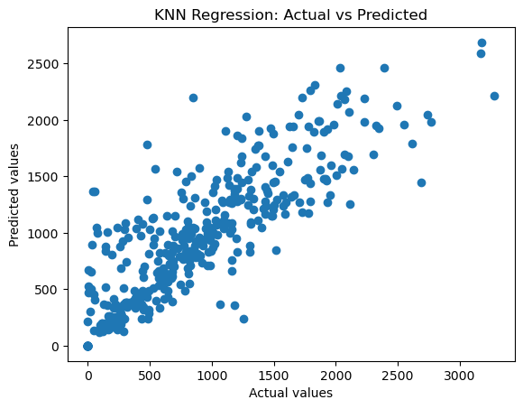

```python
# Fit the model
knn_model = KNeighborsRegressor(n_neighbors=5)
knn_model.fit(x_train, y_train)

# Predict and plot
predictions_knn = knn_model.predict(x_test)

plt.scatter(y_test, predictions_knn)
plt.xlabel('Actual values')
plt.ylabel('Predicted values')
plt.title('KNN Regression: Actual vs Predicted')
plt.show()
```

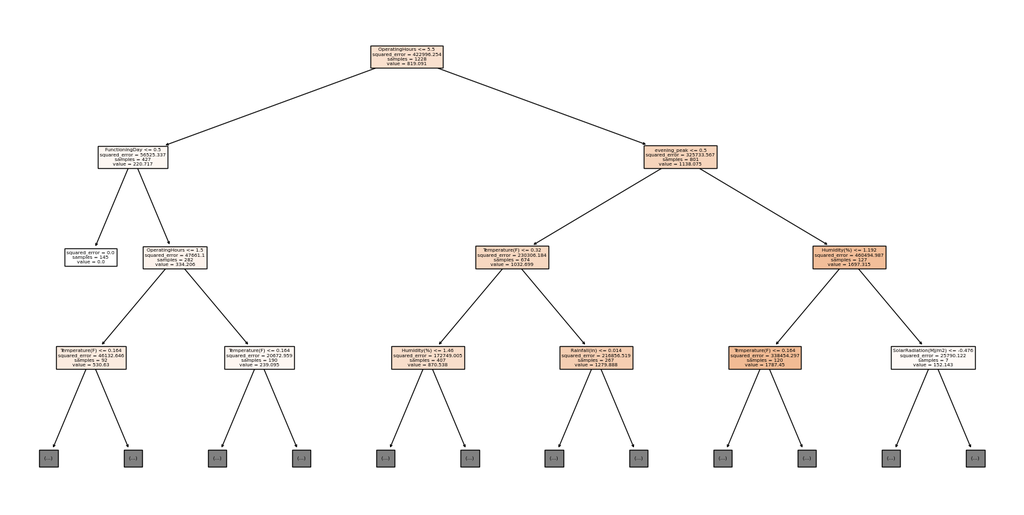

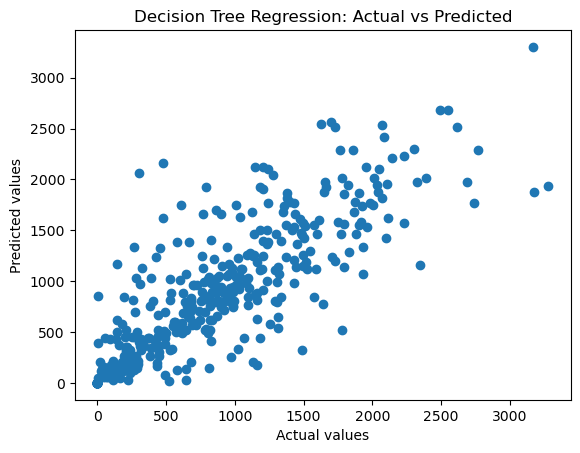

```python
# Fit the model
tree_model = DecisionTreeRegressor()
tree_model.fit(x_train, y_train)

# Tree visualization (for small trees)
plt.figure(figsize=(20,10))
plot_tree(tree_model, filled=True, feature_names=list(x_train.columns), max_depth=3)
plt.show()

# Predict and plot
predictions_tree = tree_model.predict(x_test)

plt.scatter(y_test, predictions_tree)
plt.xlabel('Actual values')
plt.ylabel('Predicted values')
plt.title('Decision Tree Regression: Actual vs Predicted')
plt.show()
```

The decision tree visualization provides a snapshot of the top three levels of the tree structure after training on the dataset. It highlights the most significant features at each decision node, indicating their threshold values and the resulting mean squared error when splitting the data at that point. The 'value' at each node indicates the average target value of the samples reaching that node, giving an idea of the predicted bike rentals for those conditions. The darker the node's color, the higher the average target value of samples in that node.

The scatter plot for the Decision Tree Regression's actual vs. predicted values shows a moderate correlation between them, implying the model captures the relationship to some extent. However, the spread of data points suggests variance in prediction accuracy, with a dense cluster in the middle range and more dispersed points at the higher end, indicating potential overfitting or model complexity issues.